# Part II CDC Heart Disease Analysis

## by Rodrigo Tiscareno

## BMI - How this it affect risk of heart disease diagnosis?

BMI is a key indicator of general health. It is derived from the ratio between a patient's weight and height. In our analysis, we found that BMI is positively correlated with a higher risk of heart disease. The higher a patient's BMI, the increased likelihood of future heart disease diagnosis. As seen from the plots, there is a slight difference in the interquartile range, median, and mean of BMI values of patients with and without heart disease. Albeit this difference is minimal as per the plot, even a 2%-3% difference can be significant. This initial investigation drove further analysis into a patient's attributes that not only affect risk of heart disease, but also general health and physical activity.

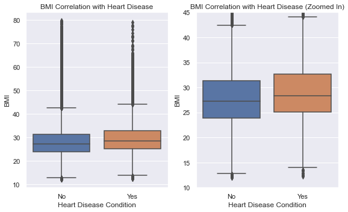

## Sleep Time - Does it play a role in preventing heart disease or lowering BMI?

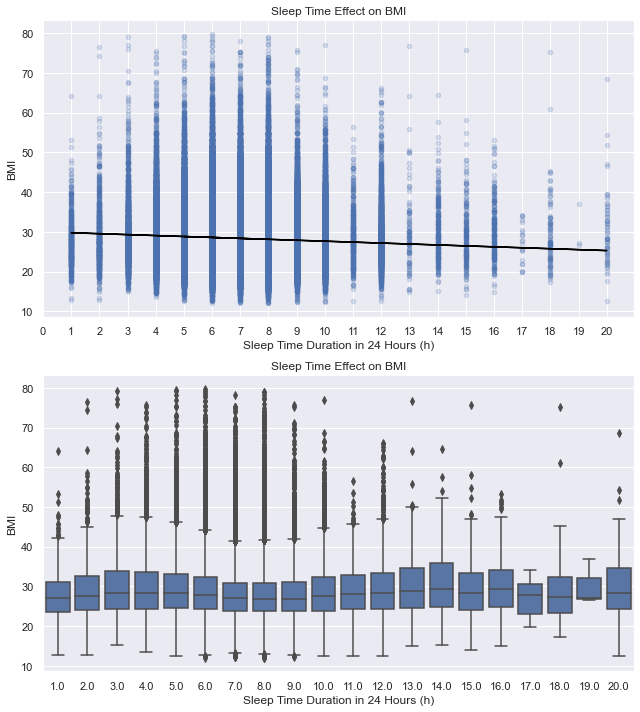

## Which age-range are more susceptible to a lower amount of sleep? How do these fluctations affect patient general health?

Different ages can expect to have different amounts of sleep. Societal strcutures and pressures could mean that adults sleep less than young adults or seniors - which was the case in this analysis. Comparing the amount of sleep across the different age categories, we were able to observe the average trends as patients transcend through life. As patients reach adulthood, their sleep time dramatically drops, resulting in a substantial variation in their general health ratings.

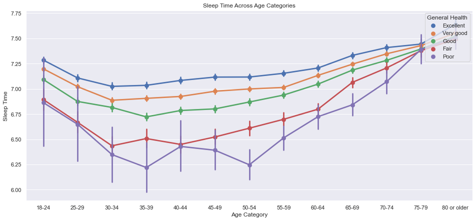

## Across all age ranges, what is the impact of physical activity to a patient's BMI?

From our previous visual, we wanted to continue our investigation into the trend of patients as they age - this time - with physical activity considerations. The first important point to observe is a the difference that physical activity plays in affecting BMI. There is a significant difference in the distance betweeen each point, specifically during adulthood. The next observation, albeit minor, is the difference in BMI as a patient ages. It can be observes that most patients reach their peak BMI during adulthood, which could potentially be tied to sleep time and societal structures as well.

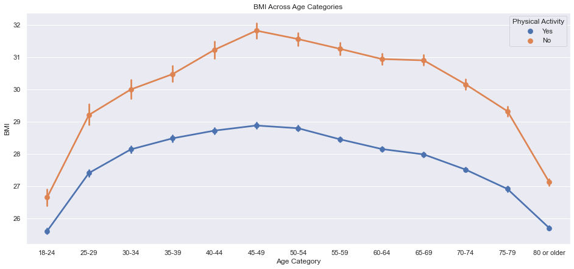

## Considering all the features in the dataset, which features are most influential in determining the risk of heart disease?

To close the analysis, we examined the top features that carried the most significance in predicting heart disease in a random forest classification model. It was concluded that patient BMI, sleep-time, physical-activity, and general health all played an essential role in predicting heart disease. I'd like to highlight that all of these factors are within our control. Through our habits, we can dictate how much physical activity we receive, how much time we sleep, and how we affect our general health through our diet.

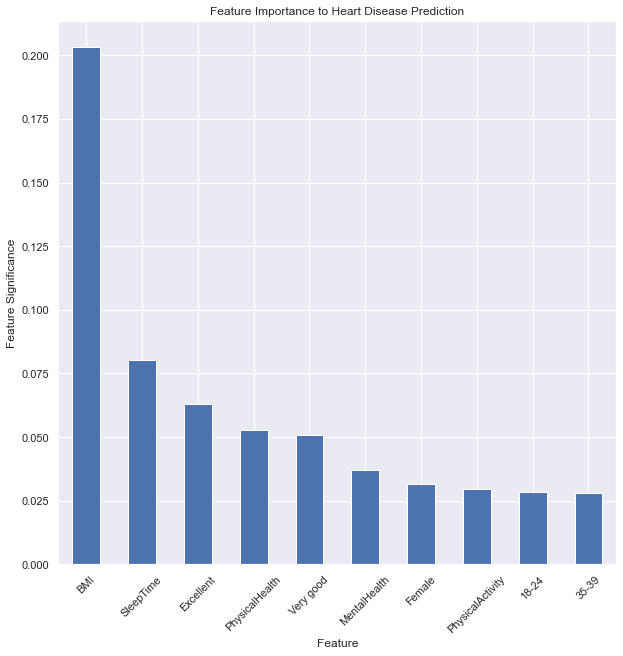